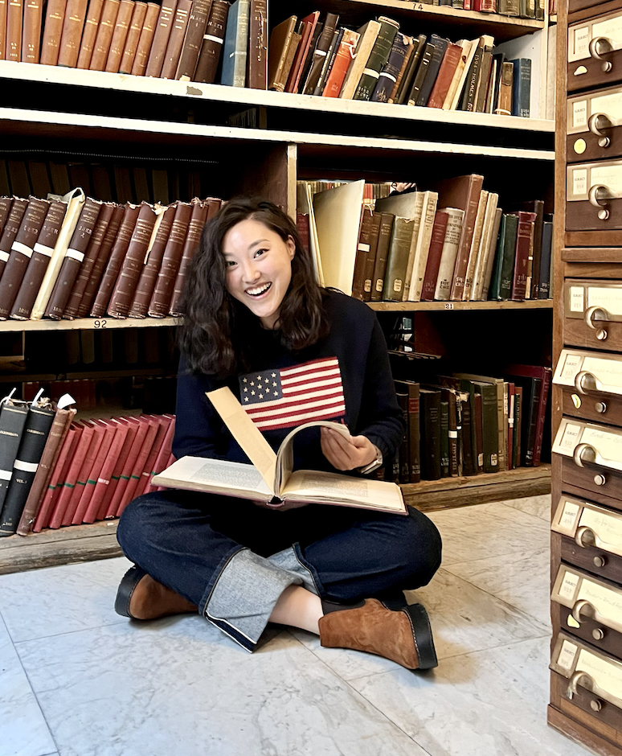

# Amanda A. Kim

Amanda Kim is currently in her doctoral training program at Johns Hopkins Bloomberg School of Public Health, under the NIH T32 Psychiatric Epidemiology training grant. Her research interests is focused on understanding the co-occurrence of autism spectrum disorder and eating disorders/disordered eating from the life course perspective.

## Education

**Johns Hopkins University** | Baltimore, MD, U.S.A.

PhD in Public Health | August 2023 - Present

**Johns Hopkins University** | Baltimore, MD, U.S.A.

MHS in Public Health | August 2021 - May 2022

**Florida Institute of Technology** | Melbourne, FL, U.S.A.

MA in Applied Behavior Analysis | August 2014 - August 2016

**University of California, Merced** | Merced, CA, U.S.A.

BA in Psychology | August 2009 - May 2013

## Certificates/Licenses

**Board Certified Behavior Analyst (BCBA 1-16-24737)** | November 2016 - present

## Experiences

**Clinical Lead Manager** | Center for Autism and Related Disorders, LLC (CARD) March 2018 - December 2020

**Clinical Supervisor** | Center for Autism and Related Disorders, LLC (CARD) December 2016 - March 2018

**Behavior Therapist** | Center for Autism and Related Disorders, LLC (CARD) June 2013 - December 2016

## Research Publications

1. Kim, A.A., Holingue, C. Co-occurring Autism Spectrum Disorder (ASD) and Eating Disorders (ED): Understanding the Heterogeneity of Study Populations. Rev J Autism Dev Disord (2024). https://doi.org/10.1007/s40489-024-00466-x
2. Kim, A., Zisman, C.R., Holingue, C. (2022). Influences of the Immune System and Microbiome on the Etiology of ASD and GI Symptomology of Autistic Individuals. In: Savitz, J., Yolken, R.H. (eds) Microorganisms and Mental Health. Current Topics in Behavioral Neurosciences, vol 61. Springer, Cham. https://doi.org/10.1007/7854_2022_371

## Awards

1. NIH T32 Training Grant: Psychiatric Epidemiology | August 2023 - Ongoing
2. AIR-P Scholar: 2024-2025 Cohort 5 | September 2024 - September 2025